# How to use tidytext and wordcloud2

Author

Jiayi Dong jd4123

# 1. Installing the package

```r
# install.packages("tidytext")
# library(devtools)
# install_github("lchiffon/wordcloud2")
```

# 2. Get text data

```r
library(gutenbergr)
library(dplyr)
Charles_Dickens_works <- gutenberg_works(author == "Dickens, Charles")
suppressWarnings(
Charles_Dickens_texts <- gutenberg_download(
  gutenberg_id = Charles_Dickens_works$gutenberg_id,
  meta_fields = c("title", "author")
)
)
```

```
Determining mirror for Project Gutenberg from https://www.gutenberg.org/robot/harvest
```

```
Using mirror http://aleph.gutenberg.org
```

```r
first_6_books <- Charles_Dickens_texts |>
  group_by(title) |>
  filter(title %in% (unique(Charles_Dickens_texts$title)[1:6])) |>
  ungroup()
head(first_6_books)
```

```
# A tibble: 6 × 4
  gutenberg_id text                         title                      author
         <int> <chr>                        <chr>                      <chr>
1          564 "The Mystery of Edwin Drood" The Mystery of Edwin Drood Dickens,…
2          564 ""                           The Mystery of Edwin Drood Dickens,…
3          564 "by Charles Dickens"         The Mystery of Edwin Drood Dickens,…
4          564 ""                           The Mystery of Edwin Drood Dickens,…
5          564 ""                           The Mystery of Edwin Drood Dickens,…
6          564 "Contents"                   The Mystery of Edwin Drood Dickens,…
```

```r
unique(first_6_books$title)
```

```
[1] "The Mystery of Edwin Drood"
[2] "The Pickwick Papers"
[3] "A Child's History of England"
[4] "The Old Curiosity Shop"
[5] "Dombey and Son"
[6] "Barnaby Rudge: A Tale of the Riots of 'Eighty"
```

# 3. Clean text data

Get only the text and book title, and add a column to check the line number. Now the data is in `one-row-per-line` format

```r
book_text <- first_6_books[, c("title", "text")] |>
  group_by(title) |>
  mutate(line = row_number()) |>
  ungroup()

head(book_text)
```

```
# A tibble: 6 × 3
  title                      text                          line
  <chr>                      <chr>                        <int>
1 The Mystery of Edwin Drood "The Mystery of Edwin Drood"     1
2 The Mystery of Edwin Drood ""                               2
3 The Mystery of Edwin Drood "by Charles Dickens"             3
4 The Mystery of Edwin Drood ""                               4
5 The Mystery of Edwin Drood ""                               5
6 The Mystery of Edwin Drood "Contents"                       6
```

But to work with a tidy dataset for text mining, we need to convert it into `one-token-per-row` format. The token here could be anything like words, characters, n-grams, sentences, etc,. `tidytext` provides a function called `unnest_tokens()`, which provides a way to convert a dataframe with a text column to be one-token-per-row.

```r
library(tidytext)
tidy_books <- book_text |>
  unnest_tokens(output = 'word', input = 'text',
                token = 'words', format = 'text')
head(tidy_books, 10)
```

```
# A tibble: 10 × 3
   title                       line word
   <chr>                      <int> <chr>
 1 The Mystery of Edwin Drood     1 the
 2 The Mystery of Edwin Drood     1 mystery
 3 The Mystery of Edwin Drood     1 of
 4 The Mystery of Edwin Drood     1 edwin
 5 The Mystery of Edwin Drood     1 drood
 6 The Mystery of Edwin Drood     3 by
 7 The Mystery of Edwin Drood     3 charles
 8 The Mystery of Edwin Drood     3 dickens
 9 The Mystery of Edwin Drood     6 contents
10 The Mystery of Edwin Drood     8 chapter
```

It acts like `pivot_longer` where line is the names are words and the values are lines. But it will help automatically get rid of empty lines.

Now, we will try to get rid of the stop words, which are insignificant for our text analysis. Here we will use `get_stopwords()` to select all the stopwords. Then we will use `anti_join()` to get all the words that are not stopwords.

```r
tidy_books_clean <- tidy_books |>
  anti_join(get_stopwords())
head(tidy_books_clean, 10)
```

```
# A tibble: 10 × 3
   title                       line word
   <chr>                      <int> <chr>
 1 The Mystery of Edwin Drood     1 mystery
 2 The Mystery of Edwin Drood     1 edwin
 3 The Mystery of Edwin Drood     1 drood
 4 The Mystery of Edwin Drood     3 charles
 5 The Mystery of Edwin Drood     3 dickens
 6 The Mystery of Edwin Drood     6 contents
 7 The Mystery of Edwin Drood     8 chapter
 8 The Mystery of Edwin Drood     8 dawn
 9 The Mystery of Edwin Drood     9 chapter
10 The Mystery of Edwin Drood     9 ii
```

After we have the cleaned words, we can use `count()` function to find the most common words in all the books combined.

```r
tidy_books_clean |>
  count(word, sort = TRUE)
```

```
# A tibble: 28,100 × 2
   word       n
   <chr>  <int>
 1 mr     11154
 2 said    9567
 3 one     4058
 4 upon    4030
 5 sir     3491
 6 man     3271
 7 old     3233
 8 little  3051
 9 time    2747
10 now     2629
# ℹ 28,090 more rows
```

# 4. Sentiment Analysis

There are four sentiment lexicons available in the function `get_sentiments()`, which are `afinn`, `bing`, `nrc`, or `loughran`. We will use `bing` here, which categorizes words in a binary fashion into positive and negative categories.

```r
get_sentiments("bing")
```

```
# A tibble: 6,786 × 2
   word        sentiment
   <chr>       <chr>
 1 2-faces     negative
 2 abnormal    negative
 3 abolish     negative
 4 abominable  negative
 5 abominably  negative
 6 abominate   negative
 7 abomination negative
 8 abort       negative
 9 aborted     negative
10 aborts      negative
# ℹ 6,776 more rows
```

Check the sentiment section by section.

```r
library(tidyr)
charlesdickenssentiment <- tidy_books_clean |>
  inner_join(get_sentiments("bing"), by = "word", relationship = "many-to-many") |>
  count(title, index = line %/% 100, sentiment) |>
  pivot_wider(names_from = sentiment, values_from = n, values_fill = 0) |>
  mutate(sentiment = positive - negative)
charlesdickenssentiment
```

```
# A tibble: 1,540 × 5
   title                        index negative positive sentiment
   <chr>                        <dbl>    <int>    <int>     <int>
 1 A Child's History of England     0       14       16         2
 2 A Child's History of England     1       32       45        13
 3 A Child's History of England     2       30       51        21
 4 A Child's History of England     3       41       23       -18
 5 A Child's History of England     4       40       26       -14
 6 A Child's History of England     5       39       38        -1
 7 A Child's History of England     6       34       64        30
 8 A Child's History of England     7       33       67        34
 9 A Child's History of England     8       53       46        -7
10 A Child's History of England     9       40       41         1
# ℹ 1,530 more rows
```

Plot the sentiment for each book.

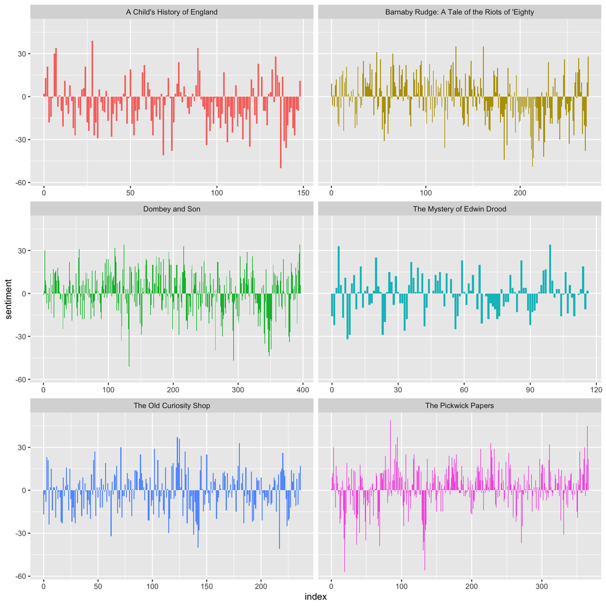

```r
library(ggplot2)

ggplot(charlesdickenssentiment, aes(index, sentiment, fill = title)) +
  geom_col(show.legend = FALSE) +
  facet_wrap(vars(title), ncol = 2, scales = "free_x")
```

# 5. Visualization with Wordcloud2

Not for serious data analysis and visualization!!!

```r
library(wordcloud2)
word_count <- tidy_books_clean |>
                count(word, sort = TRUE)
wordcloud2(data = word_count, minSize=8)
```

[interactive chart not shown]